# Hypergraphs: relations that bind more than two nodes

honets

2026-08-26

> Each section below is one verb, worked end to end on the same data. The sections run in order in a single R session, so later ones may reuse objects the earlier ones built.

## build_hypergraph(): promoting cliques to group interactions

### The analytic question

Sometimes only pairwise data is available, but the process being studied is plausibly a group process. Three people who all know each other might form a genuine three-way relationship — or they might just be three separate friendships that happen to close a triangle. A graph cannot tell you which.

`build_hypergraph()` takes the position of Burgio et al. (2020): treat each triangle (and larger clique) as a **candidate** group interaction, and promote it to a hyperedge with probability `p`. At `p = 1` every clique becomes a group; at `p = 0` none do and the pairwise structure is preserved unchanged. The parameter is an explicit statement of how much you believe triadic closure implies group interaction.

If you *observe* group membership directly, do not infer it — use `group_hypergraph()` instead. If your data are sequences, use `window_hypergraph()`.

```r
library(honets)
set.seed(1)
m <- matrix(runif(100), 10, 10)
m <- (m + t(m)) / 2
diag(m) <- 0
dimnames(m) <- list(LETTERS[1:10], LETTERS[1:10])
```

```r
library(cograph)
```

### Building one

```r
hg <- build_hypergraph(m, threshold = 0.5)
hg
```

```
Hypergraph: 10 nodes, 39 hyperedges
Size distribution:
  size_2   : 24
  size_3   : 15
Source: network cliques (p = 1.00, include_pairwise = TRUE, max_size = 3)
```

24 pairwise edges retained as 2-hyperedges, plus 15 triangles promoted to 3-hyperedges.

```r
as.data.frame(hg, top = 6)
```

```
  hyperedge size states weight
1        h1    2   E, I     NA
2        h2    2   F, J     NA
3        h3    2   G, J     NA
4        h4    2   E, J     NA
5        h5    2   A, I     NA
6        h6    2   A, F     NA
```

`weight` is `NA` here: hyperedges from cliques are unweighted. Only `window_hypergraph()` produces weights, from window counts.

### Seeing it

A hypergraph has no direct network drawing, but `clique_expansion()` projects it back to a pairwise network that cograph plots directly. Read it knowing what the projection destroys: every hyperedge became a clique, and the group boundaries are gone.

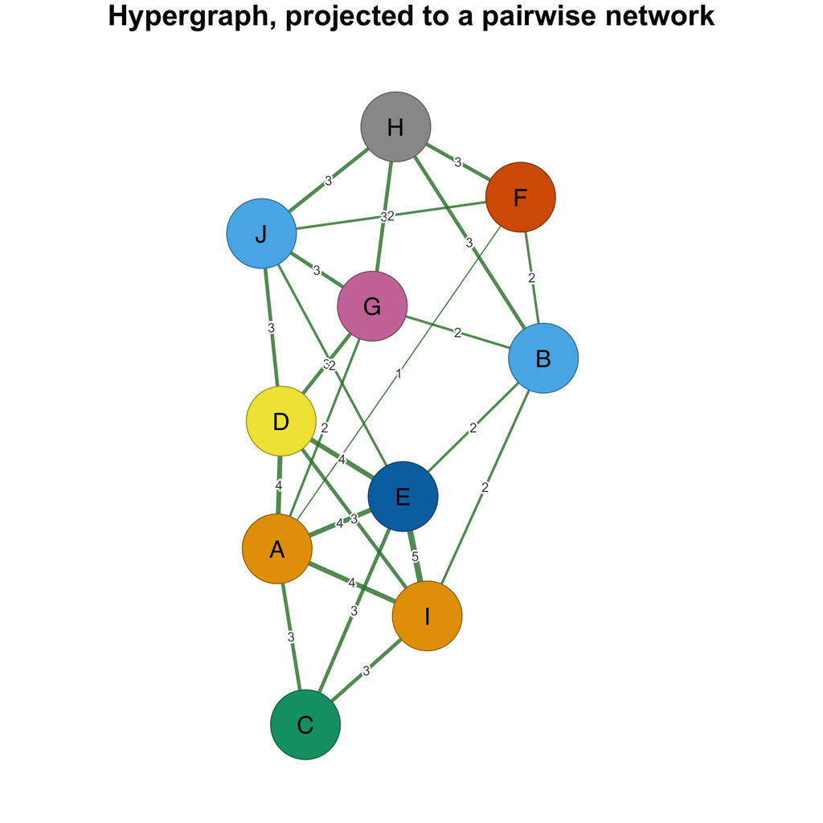

```r
net <- clique_expansion(hg)
splot(net, minimum = 0.05,
      title = "Hypergraph, projected to a pairwise network")
```

### `p` is the modelling assumption

```r
do.call(rbind, lapply(c(0, 0.25, 0.5, 0.75, 1), function(p) {
  h <- build_hypergraph(m, threshold = 0.5, p = p, seed = 1)
  edges_h <- as.data.frame(h)
  data.frame(p = p, hyperedges = nrow(edges_h),
             pairwise = sum(edges_h$size == 2),
             triples = sum(edges_h$size == 3))
}))
```

```
     p hyperedges pairwise triples
1 0.00         24       24       0
2 0.25         28       24       4
3 0.50         32       24       8
4 0.75         35       24      11
5 1.00         39       24      15
```

At `p = 0` you get 24 hyperedges, all of size 2 — the original graph, re-expressed. At `p = 1`, all 15 triangles are promoted. In between, the sampling is Bernoulli per clique, so **`seed` is required for reproducibility**:

```r
first <- build_hypergraph(m, threshold = 0.5, p = 0.5, seed = 42)
second <- build_hypergraph(m, threshold = 0.5, p = 0.5, seed = 42)
identical(first, second)
```

```
[1] TRUE
```

Never report a result at `0 < p < 1` from a single draw. Repeat across seeds and report the variability, exactly as you would for any stochastic method.

```r
sizes <- vapply(1:20, function(s) {
  h <- build_hypergraph(m, threshold = 0.5, p = 0.5, seed = s)
  edges_h <- as.data.frame(h)
  nrow(edges_h)
}, integer(1))
range(sizes)
```

```
[1] 27 35
```

### `include_pairwise` — a hypergraph of groups only

```r
build_hypergraph(m, threshold = 0.5, include_pairwise = FALSE)
```

```
Hypergraph: 10 nodes, 15 hyperedges
Size distribution:
  size_3   : 15
Source: network cliques (p = 1.00, include_pairwise = FALSE, max_size = 3)
```

`FALSE` drops the 2-hyperedges, giving a “fully higher-order” hypergraph containing only the k ≥ 3 interactions. Use it to isolate the group structure from the dyadic structure — for instance to check whether a centrality result survives when the pairwise scaffolding is removed.

### `max_size` and `threshold`

```r
do.call(rbind, lapply(c(3, 4, 5), function(ms) {
  h <- build_hypergraph(m, threshold = 0.5, max_size = ms)
  edges_h <- as.data.frame(h)
  data.frame(max_size = ms, hyperedges = nrow(edges_h))
}))
```

```
  max_size hyperedges
1        3         39
2        4         41
3        5         41
```

`max_size = 3` (the default) keeps triangles. Raising it to 4 finds two 4-cliques; there are no 5-cliques, so 5 adds nothing. Unlike the Vietoris-Rips complex in `build_simplicial()`, this does **not** explode combinatorially, because only maximal-clique membership is enumerated rather than every face.

`threshold` binarises the weight matrix before clique-finding, and it moves the result far more than `max_size` does:

```r
do.call(rbind, lapply(c(0.3, 0.5, 0.7), function(t) {
  h <- build_hypergraph(m, threshold = t)
  edges_h <- as.data.frame(h)
  data.frame(threshold = t, hyperedges = nrow(edges_h),
             pairwise = sum(edges_h$size == 2),
             triples = sum(edges_h$size == 3))
}))
```

```
  threshold hyperedges pairwise triples
1       0.3        122       40      82
2       0.5         39       24      15
3       0.7          8        8       0
```

### `type = "vr"` raises rather than pretending

```r
build_hypergraph(m, type = "vr")
```

```
Error:
! type = "vr" (Vietoris-Rips) is not implemented. A genuine metric Vietoris-Rips construction requires a distance-ball graph, which this package does not build. Use type = "clique" (cliques in the binarised adjacency).
```

A genuine metric Vietoris-Rips construction needs a distance-ball graph, which this verb does not build. Rather than silently aliasing `"clique"` and giving you a result labelled something it is not, it stops. Use `build_simplicial(type = "vr")` if you want a real VR construction.

### What to do next

- **`hypergraph_measures()`** — hyperdegree, overlap and density for the object you just built.
- **`hypergraph_centrality()`** — which nodes matter, by tensor eigenvector or EDVW PageRank.
- **`clique_expansion()`** — project back to a pairwise network, and see what the round trip costs.
- **`group_hypergraph()`** — when membership is observed rather than inferred.

### References

- Burgio, G., Matamalas, J. T., Gómez, S., & Arenas, A. (2020). Evolution of cooperation in the presence of higher-order interactions: from networks to hypergraphs. *Entropy*, 22(7), 744.
- Battiston, F., et al. (2020). Networks beyond pairwise interactions. *Physics Reports*, 874, 1-92.

## Windowed sequence hyperedges: multi-way co-occurrence in coded sequences

### The analytic question

Coded interaction sequences record one action at a time: a person specifies a requirement, the partner interrupts, a command follows. A transition network answers *what follows what*; a co-occurrence network answers *which pairs appear together*. Neither answers the question this tutorial takes up: **which actions occur together as groups within short spans of activity, and do those groups recur often enough to constitute a structure?**

A pairwise network cannot hold the answer, because a group of three actions inside one span is not the same observation as its three pairs. The hypergraph keeps the group intact: each short span of a sequence becomes one *hyperedge* over the distinct actions inside it. The construction follows Ding, Wang, Li, Li & Liu (2020); the resulting weighted incidence matrix carries edge-dependent vertex weights in the sense of Chitra & Raphael (2019), which the spectral machinery of Zhou, Huang & Schölkopf (2006) and Hayashi, Aksoy, Park & Park (2020) consumes directly.

The data are `human_long`, bundled with honets: 10,796 coded human turns from 429 human–AI pair-programming sessions, nine action codes, each code carrying an a-priori cluster label (Directive, Evaluative, Metacognitive) that the analysis below never uses — it will serve as an external check at the end.

```r
library(honets)
```

```r
library(cograph)
```

### How a sequence becomes a hypergraph

Before the real data, a four-event sequence small enough to verify by hand. With `window = 2` the windows are (a,b), (b,a), (a,c); the first two contain the same set of states, so they collapse into one hyperedge observed twice.

```r
hg_tiny <- window_hypergraph(list(s1 = c("a", "b", "a", "c")), window = 2L)
as.data.frame(hg_tiny)
```

```
  hyperedge size states weight
1        h1    2   a, b      2
2        h2    2   a, c      1
```

The table has one row per hyperedge. The set {a, b} was seen in 2 windows (`weight = 2`), the set {a, c} in 1. Weight is therefore *recurrence*: how many spans of the sequence produced exactly this combination. Repeats inside a window count as occurrences in the incidence matrix but not as extra members — a window (a, a) yields the singleton hyperedge {a} with an incidence cell of 2. This is what makes the incidence matrix edge-dependent-weighted rather than binary.

### Recurrent action combinations in real sessions

Which combinations of actions recur inside three-turn spans of the sessions? The long format goes in directly: `action` names the code column, `actor` groups turns into sessions, `time` orders them.

```r
hg_all <- window_hypergraph(human_long, action = "code",
                            actor = "session_id", time = "timestamp",
                            window = 3L)
hg_all
```

```
Hypergraph: 9 nodes, 129 hyperedges
Size distribution:
  size_1   : 9
  size_2   : 36
  size_3   : 84
Source: windowed sequences, window = 3, step = 1 (9942 windows from 429 sequences)
```

The 429 sessions produce 9,942 windows (six sessions were shorter than three turns and contributed none — the constructor counts them rather than dropping them silently). The 129 hyperedges are exactly the 9 singletons, 36 pairs, and 84 triples that nine codes allow: with this much data, *every possible combination occurs at least once*. Presence alone is saturated, so any presence-based summary would be flat. The information is in the weights:

```r
as.data.frame(hg_all, sort_by = "weight", top = 10)
```

```
   hyperedge size                      states weight
1        h35    2            Command, Specify    722
2        h33    3   Command, Request, Specify    583
3       h124    2            Request, Specify    344
4        h26    3 Command, Interrupt, Specify    340
5       h120    2             Refine, Specify    295
6       h111    3 Interrupt, Request, Specify    265
7        h86    2          Frustrate, Specify    202
8       h118    3    Refine, Request, Specify    199
9        h21    3   Command, Inquire, Specify    190
10        h1    1                     Command    177
```

Since rare combinations are noise for structural analysis, the `min_weight` argument keeps only recurrent ones — the same role `min_freq` plays in higher-order rule extraction. Fifty windows out of 9,942 is a conservative floor; `min_size = 2` also removes the nine singletons, which carry no co-occurrence information.

```r
hg <- window_hypergraph(human_long, action = "code",
                        actor = "session_id", time = "timestamp",
                        window = 3L, min_size = 2L, min_weight = 50L)
hg
```

```
Hypergraph: 9 nodes, 56 hyperedges
Size distribution:
  size_2   : 22
  size_3   : 34
Source: windowed sequences, window = 3, step = 1 (9942 windows from 429 sequences)
```

Fifty-six combinations — 22 pairs and 34 triples — recur at least 50 times. This is the structure the rest of the analysis works on.

### Seeing the recurrent combinations

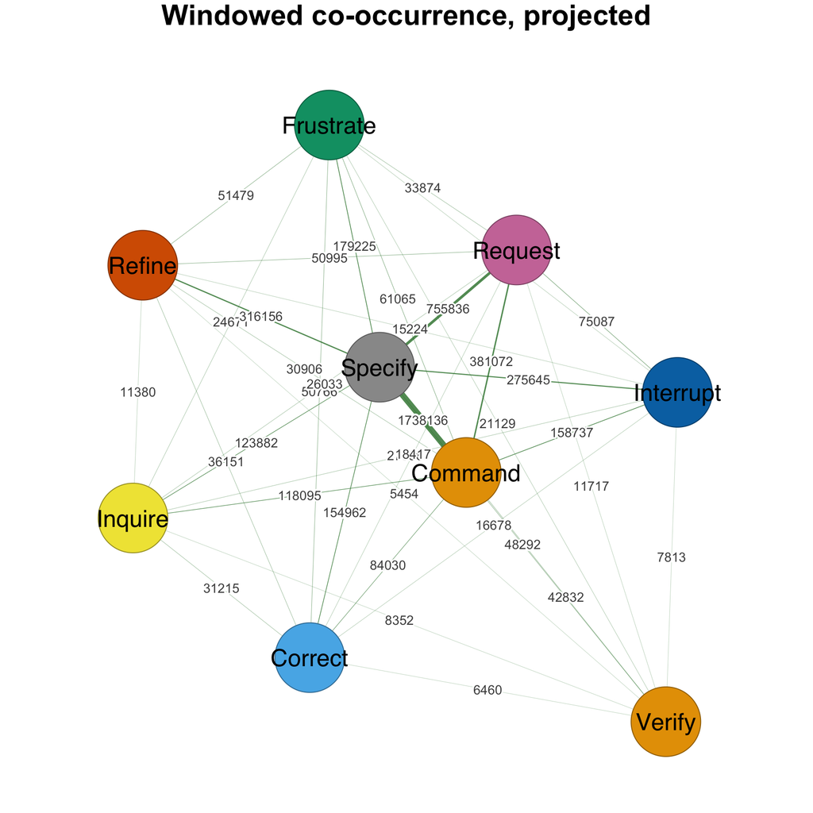

```r
net_all <- clique_expansion(hg_all)
splot(net_all, minimum = 0.05,
      title = "Windowed co-occurrence, projected")
```

### How concentrated is the recurrent structure?

```r
hypergraph_measures(hg)
```

```
Hypergraph measures: 9 nodes, 56 hyperedges
  Density:                0.2897
  Mean edge size:         2.61
  Pairwise participation: 0.9167

  Hyperdegree:    min=8  med=15.0  max=33
  Node strength:  min=21.0  med=40.0  max=91.0
  Edge sizes:     min=2  med=3.0  max=3

Intersection profile (pair counts by overlap size):
  overlap_0   : 474
  overlap_1   : 802
  overlap_2   : 264
```

Three numbers matter here. First, hyperdegree now ranges from 8 to 33 (median 15): after filtering, the codes participate in very different numbers of recurrent combinations, where the unfiltered hypergraph had forced every code to the same value. Second, pairwise participation is 0.92 — almost every pair of codes still shares at least one recurrent hyperedge, so the structure is concentrated but not fragmented. Third, the intersection profile shows 264 hyperedge pairs overlapping in two codes: the triples are largely *extensions* of the strong pairs (for example `Command, Specify` extending to `Command, Request, Specify`), not separate formations.

### Which actions anchor the combinations?

The H-eigenvector centrality of Benson (2019) scores each node on the uniform-size hypergraph tensor; unlike degree it rewards being in combinations whose *other members* are themselves central.

```r
hypergraph_centrality(hg, type = "H")
```

```
       node         H
1   Command 0.3773413
2   Correct 0.3337657
3 Frustrate 0.3637328
4   Inquire 0.3340307
5 Interrupt 0.2831700
6    Refine 0.2820356
7   Request 0.3043738
8   Specify 0.4281911
9    Verify 0.2580999
```

Specify (0.43) is the clear anchor, with Command (0.38) second — the two directive actions sit inside most strong combinations. Verify (0.26), Refine (0.28), and Interrupt (0.28) are peripheral: they occur, and recur, but in combinations anchored by others. The ordering matches what the top-weight table already suggested, now as a single per-node score.

### Do the actions organize into higher-order groups?

The random-walk Laplacian of Hayashi et al. (2020) uses both weight layers this hypergraph carries: the occurrence-count incidence (edge-dependent vertex weights) and the window counts, which `hypergraph_cluster()` picks up automatically as hyperedge weights. Hayashi et al. provide two clustering branches: RDC-Spec uses the smallest Laplacian eigenvectors and k-means, while RDC-Sym factorizes the normalized similarity as `T ~= U U'` and assigns each node to its largest factor. Both are available through `algorithm =`. Spectral k-means is stochastic, so the run is seeded and repeated under a second seed as a stability check.

```r
cl <- hypergraph_cluster(hg, k = 2L, type = "random_walk", seed = 1)
cl_check <- hypergraph_cluster(hg, k = 2L, type = "random_walk", seed = 99)
membership <- as.data.frame(cl)
membership_check <- as.data.frame(cl_check)
identical(membership, membership_check)
```

```
[1] TRUE
```

```r
membership
```

```
       node   cluster         pi       dim1        dim2
1   Command Cluster 1 0.18476075 -0.7666588  0.64205472
2   Correct Cluster 2 0.07342118 -0.6251948 -0.78046872
3 Frustrate Cluster 2 0.08513619 -0.4829078 -0.87567123
4   Inquire Cluster 1 0.07212750 -0.8292714  0.55884608
5 Interrupt Cluster 1 0.07125103 -0.6293613  0.77711286
6    Refine Cluster 2 0.06733948 -0.4364170 -0.89974453
7   Request Cluster 1 0.10781145 -0.9215039  0.38836921
8   Specify Cluster 1 0.30937849 -0.9979768  0.06357931
9    Verify Cluster 1 0.02877393 -0.7116741  0.70250975
```

```r
cl_sym <- hypergraph_cluster(
  hg, k = 2L, type = "random_walk", algorithm = "symnmf",
  nstart = 5L, seed = 1
)
cl_sym
```

```
Hypergraph RDC-Sym symmetric-NMF clustering (random_walk Laplacian)
  Nodes: 9 | Hyperedges: 56 | k: 2
  Cluster sizes: Cluster 1 = 6, Cluster 2 = 3
  Objective: 0.622578 | Iterations: 211 | Converged: yes
```

```r
as.data.frame(cl_sym)
```

```
       node   cluster         pi         dim1         dim2
1   Command Cluster 1 0.18476075 0.0586181214 0.4910185864
2   Correct Cluster 2 0.07342118 0.3411781418 0.0836285574
3 Frustrate Cluster 2 0.08513619 0.4597582005 0.0213844409
4   Inquire Cluster 1 0.07212750 0.0563903976 0.2919055986
5 Interrupt Cluster 1 0.07125103 0.0002297498 0.3365210202
6    Refine Cluster 2 0.06733948 0.4391712963 0.0005270576
7   Request Cluster 1 0.10781145 0.1196526339 0.3196329488
8   Specify Cluster 1 0.30937849 0.3127446858 0.4602087829
9    Verify Cluster 1 0.02877393 0.0146147793 0.2005628865
```

RDC-Sym exposes the final Eq. 16 loss, its objective trace, iteration count, and convergence flag under `cl_sym$params`. The paper’s J-NMF and JS-NMF methods are also implemented as `hypergraph_joint_cluster()`, but require a separate node-by-node relation matrix (patent citations in the paper). They are intentionally not invoked here because this sequence data has no such second view.

The partition is identical under both seeds, so it can be reported as stable. Cluster 2 is {Correct, Frustrate, Refine}; Cluster 1 is everything else, with Specify holding the largest stationary probability (`pi = 0.31`) — a random walker on the recurrent combinations spends almost a third of its time on Specify.

This is where the withheld labels come in: the coding scheme’s Evaluative cluster is {Correct, Frustrate, Refine, Verify}. The hypergraph recovered three of its four members from co-occurrence structure alone. The defector is informative: Verify co-occurs with Specify and Command (the combinations `Command, Specify, Verify` and `Request, Specify, Verify` each recur over 80 times), so *within short spans* verification behaves as part of the directive workflow, not the evaluative one.

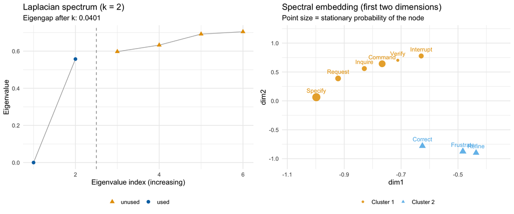

```r
plot(cl)
```

### Does the window size change the conclusions?

Window size is the one consequential arbitrary choice in this pipeline, so the headline result must survive a different value.

```r
hg4 <- window_hypergraph(human_long, action = "code",
                         actor = "session_id", time = "timestamp",
                         window = 4L, min_size = 2L, min_weight = 50L)
as.data.frame(hg4, sort_by = "weight", top = 8)
```

```
  hyperedge size                               states weight
1       h24    3            Command, Request, Specify    447
2       h20    3          Command, Interrupt, Specify    357
3       h26    2                     Command, Specify    343
4       h19    4 Command, Interrupt, Request, Specify    241
5       h50    3             Refine, Request, Specify    221
6       h17    3            Command, Inquire, Specify    212
7        h8    3            Command, Correct, Specify    173
8       h52    2                     Request, Specify    168
```

With four-turn windows the same combinations lead: `Command, Request, Specify` (447), `Command, Interrupt, Specify` (357), `Command, Specify` (343), and their four-code extension `Command, Interrupt, Request, Specify` now enters at 241 — wider windows admit larger sets, but the membership of the dominant combinations is unchanged. The conclusion — directive combinations anchored by Specify dominate, corrective actions form their own block — does not depend on the choice of three versus four.

### The same sessions as a temporal hypergraph

`window_hypergraph()` answers which combinations recur, and forgets *when* in a session they occurred. `temporal_hypergraph()` keeps that: read the same log with the session as the hyperedge, the code as the member and the turn’s position as its time, and every session becomes one hyperedge whose members enter at their step. The clock is order. Here `order_in_session` counts every turn of the session, the partner’s included, so a human turn’s step is its place among all turns. A wide table of states, one row per session and one column per position, needs no column names at all.

```r
sessions <- temporal_hypergraph(human_long, actor = "code",
                                group = "session_id",
                                time = "order_in_session")
sessions
```

```
Temporal hypergraph: 9 nodes, 429 hyperedges, 285 event times
Format: interval; memberships carry their own times (a hyperedge spans its first to its last membership)
Time: time (numeric steps); observed from 1 to 287
```

A snapshot with `window = 3` at step 5 is the co-occurrence hypergraph of steps 5 to 7: one hyperedge per session still running, over the codes of its human turns among those three turns. Most sessions show one or two codes there, because the partner holds some of the three turns; `window_hypergraph()` above windows over consecutive human turns instead, which is why its sets are larger.

```r
steps_five_to_seven <- hypergraph_snapshot(sessions, at = 5, window = 3)
steps_five_to_seven
```

```
Hypergraph: 9 nodes, 417 hyperedges
Size distribution:
  size_1   : 326
  size_2   : 87
  size_3   : 4
Source: group membership (member = member, group = edge)
```

`mode = "cumulative"` at a step is what each session had shown by then, and `hg_growth()` follows the memberships as they enter.

```r
growth_sessions <- hg_growth(sessions, mode = "cumulative")
head(growth_sessions, 5)
```

```
  time n_nodes n_edges n_edges_distinct n_memberships
1    1       6     429                6           429
2    2       8     429               10           803
3    3       8     429               14          1192
4    4       9     429               25          1525
5    5       9     429               32          1721
```

### When to use which

- **`temporal_hypergraph()`** — sequences, and the question is about *when* combinations occur: what a session had shown by a step, or on a span of steps, with the session kept intact as one hyperedge.
- **`window_hypergraph()`** — sequences, and the question is about combinations *local in time*. `step = 1` (sliding) weights every span; `step = window` (tumbling) counts disjoint spans and suits length comparisons across groups. Raise `min_weight` before structural analysis on dense data; this tutorial’s saturation of all 129 possible sets is the norm, not the exception, once windows are plentiful.
- **`group_hypergraph()`** — the grouping is already categorical (a whole session, a document, a team) and position in time is irrelevant. A whole-sequence window reproduces it exactly.
- **`build_hypergraph()`** — the input is an estimated pairwise network and the hyperedges should be its cliques.
- **`clique_expansion()`** — hands the hypergraph back to pairwise machinery in cograph when a graph method is needed; the multi-way distinctions collapse into edge weights at that point, which is exactly what this tutorial’s construction exists to avoid.

### References

- Benson, A. R. (2019). Three hypergraph eigenvector centralities. *SIAM Journal on Mathematics of Data Science*, 1(2), 293–312.
- Chitra, U., & Raphael, B. J. (2019). Random walks on hypergraphs with edge-dependent vertex weights. *ICML 2019*, PMLR 97, 1172–1181.
- Ding, K., Wang, J., Li, J., Li, D., & Liu, H. (2020). Be more with less: Hypergraph attention networks for inductive text classification. *EMNLP 2020*, 4927–4936.
- Hayashi, K., Aksoy, S. G., Park, C. H., & Park, H. (2020). Hypergraph random walks, Laplacians, and clustering. *CIKM 2020*, 495–504.
- Zhou, D., Huang, J., & Schölkopf, B. (2006). Learning with hypergraphs: Clustering, classification, and embedding. *NeurIPS 2006*, 1601–1608.

## group_hypergraph(): when membership is observed

### The analytic question

A great deal of data is *already* group data. Authors on a paper. Students in a seminar. Codes applied in one session. Items in one basket. The group membership is recorded directly — nothing needs inferring.

The usual move is to project it to a pairwise network: everyone in a group gets connected to everyone else. That projection **destroys information** irreversibly. A five-author paper and ten separate two-author papers can produce exactly the same graph, and no analysis of the graph can tell them apart.

`group_hypergraph()` skips the projection. Each group becomes one hyperedge spanning all its members, and the group size survives into the analysis.

```r
library(honets)
```

```r
library(cograph)
```

### Building one

Long-format data: one row per (member, group) observation.

```r
hg <- group_hypergraph(human_long, actor = "code", group = "session_id")
hg
```

```
Hypergraph: 9 nodes, 429 hyperedges
Size distribution:
  size_1   : 5
  size_2   : 3
  size_3   : 20
  size_4   : 32
  size_5   : 62
  size_6   : 77
  size_7   : 75
  size_8   : 75
  size_9   : 80
Source: group membership (member = code, group = session_id)
```

429 sessions become 429 hyperedges over the 9 action codes. The size distribution is the thing a pairwise projection would have thrown away: **80 sessions used all nine codes**, while five used only one.

```r
as.data.frame(hg, top = 4)
```

```
     hyperedge size
1 0086cabebd15    6
2 00bd84ef1666    3
3 00da7e5a052d    9
4 0162fe521f0c    9
                                                                             states
1                           Command, Frustrate, Inquire, Interrupt, Specify, Verify
2                                                       Command, Interrupt, Specify
3 Command, Correct, Frustrate, Inquire, Interrupt, Refine, Request, Specify, Verify
4 Command, Correct, Frustrate, Inquire, Interrupt, Refine, Request, Specify, Verify
  weight
1     NA
2     NA
3     NA
4     NA
```

### A small worked example

```r
df <- data.frame(
  person  = c("Alice", "Bob", "Carol", "Alice", "Bob", "Dave", "Carol",
              "Dave", "Eve"),
  session = c("S1", "S1", "S1", "S2", "S2", "S3", "S3", "S3", "S3"),
  stringsAsFactors = FALSE
)
small <- group_hypergraph(df, actor = "person", group = "session")
small
```

```
Hypergraph: 5 nodes, 3 hyperedges
Size distribution:
  size_2   : 1
  size_3   : 2
Source: group membership (member = person, group = session)
```

```r
as.data.frame(small)
```

```
  hyperedge size            states weight
1        S1    3 Alice, Bob, Carol     NA
2        S2    2        Alice, Bob     NA
3        S3    3  Carol, Dave, Eve     NA
```

Three sessions, three hyperedges: a triple, a pair, and another triple. Note that S1 = {Alice, Bob, Carol} is **one** relation, not three.

### Seeing it

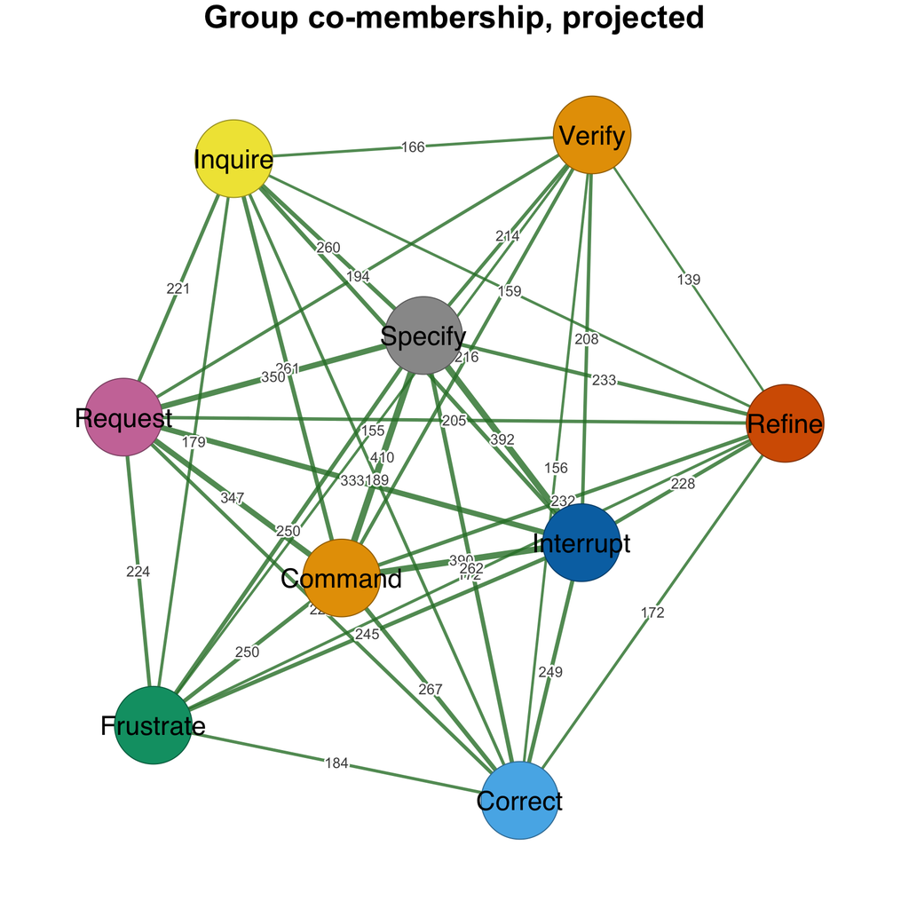

```r
net <- clique_expansion(hg)
splot(net, minimum = 0.05,
      title = "Group co-membership, projected")
```

### Weighted membership

If the data record a quantity per (member, group) pair — hours contributed, messages sent, counts — pass the column as `weight` and the incidence matrix carries it.

```r
dfw <- data.frame(
  person  = c("A", "B", "A", "A", "B"),
  grp     = c("g1", "g1", "g1", "g2", "g2"),
  n       = c(2, 5, 3, 1, 4),
  stringsAsFactors = FALSE
)
hw <- group_hypergraph(dfw, actor = "person", group = "grp", weight = "n")
as.data.frame(hw, what = "memberships")
```

```
  node hyperedge weight
1    A        g1      5
2    B        g1      5
3    A        g2      1
4    B        g2      4
```

Repeated `(member, group)` pairs are **summed**: A appears twice in `g1` with 2 and 3, giving 5. Without `weight`, the incidence is 0/1 and repeats simply collapse:

```r
hb <- group_hypergraph(dfw, actor = "person", group = "grp")
as.data.frame(hb, what = "memberships")
```

```
  node hyperedge weight
1    A        g1      1
2    B        g1      1
3    A        g2      1
4    B        g2      1
```

Those edge-dependent vertex weights are exactly what `hypergraph_centrality(type = "pagerank")` and the Laplacian family consume — a weighted hypergraph carries information a binary one does not.

### Missing values are dropped silently

```r
dfn <- data.frame(
  person = c("A", "B", NA, "C", "D"),
  grp    = c("g1", "g1", "g1", NA, "g2"),
  stringsAsFactors = FALSE
)
group_hypergraph(dfn, actor = "person", group = "grp")
```

```
Hypergraph: 3 nodes, 2 hyperedges
Size distribution:
  size_1   : 1
  size_2   : 1
Source: group membership (member = person, group = grp)
```

Rows with `NA` in either column are removed before construction. Check your own missingness before calling — this verb will not warn you about it, and a silently shrunken hypergraph is easy to miss.

### What the group structure buys you

```r
m <- hypergraph_measures(hg)
as.data.frame(m, what = "global")
```

```
                 measure       value
1                n_nodes   9.0000000
2           n_hyperedges 429.0000000
3                density   0.7293447
4          avg_edge_size   6.5641026
5 pairwise_participation   1.0000000
```

**Pairwise participation is 1.0**: every pair of codes co-occurs in at least one session. A projected pairwise network would therefore be the *complete graph on nine nodes* — utterly uninformative, exactly as the first-order transition network is in the three-families comparison.

The hypergraph keeps its information because the hyperedges remain distinguishable by size and membership:

```r
hg_measures(hg, what = "distribution", measure = "size")
```

```
  value  n  proportion      ccdf
1     1  5 0.011655012 1.0000000
2     2  3 0.006993007 0.9883450
3     3 20 0.046620047 0.9813520
4     4 32 0.074592075 0.9347319
5     5 62 0.144522145 0.8601399
6     6 77 0.179487179 0.7156177
7     7 75 0.174825175 0.5361305
8     8 75 0.174825175 0.3613054
9     9 80 0.186480186 0.1864802
```

### What to do next

- **`hypergraph_measures()`** — hyperdegree, overlap structure and density.
- **`hypergraph_centrality()`** — which members are central across the groups.
- **`hypergraph_cluster()`** — group the members by the hypergraph’s own random walk.
- **`clique_expansion()`** — the projection this verb avoids, when you deliberately want it.
- **`window_hypergraph()`** — the sequence-based route to a hypergraph, when groups are local in time rather than given.

## hypergraph_measures(): structure without a projection

### The analytic question

Graph descriptives — degree, density, clustering — all assume relations come in pairs. Applied to a projected hypergraph they answer questions about the projection rather than about the data.

`hypergraph_measures()` computes the equivalents directly on the hypergraph: how many groups is each node in, how large are the groups, and how much do the groups overlap. The last of these has no graph analogue at all, and is usually the most informative.

```r
library(honets)
hg <- group_hypergraph(human_long, actor = "code", group = "session_id")
m <- hypergraph_measures(hg)
m
```

```
Hypergraph measures: 9 nodes, 429 hyperedges
  Density:                0.7293
  Mean edge size:         6.56
  Pairwise participation: 1.0000

  Hyperdegree:    min=218  med=268.0  max=423
  Node strength:  min=1666.0  med=1967.0  max=2796.0
  Edge sizes:     min=1  med=7.0  max=9

Intersection profile (pair counts by overlap size):
  overlap_0   : 96
  overlap_1   : 2960
  overlap_2   : 3235
  overlap_3   : 10827
  overlap_4   : 18272
  overlap_5   : 20355
  overlap_6   : 15746
  overlap_7   : 10601
  overlap_8   : 6554
  overlap_9   : 3160
```

```r
library(cograph)
```

### Per-node measures

```r
as.data.frame(m, sort_by = "hyperdegree")
```

```
       node hyperdegree node_strength max_edge_size
1   Command         423          2796             9
2   Specify         415          2786             9
3 Interrupt         393          2691             9
4   Request         353          2447             9
5   Correct         268          1967             9
6   Inquire         261          1949             9
7 Frustrate         252          1911             9
8    Refine         233          1773             9
9    Verify         218          1666             9
```

- **`hyperdegree`** — how many hyperedges contain this node. Command appears in 423 of 429 sessions.
- **`node_strength`** — the summed incidence weight. On a binary incidence this is a weighted count; the gap between it and hyperdegree tells you how much the weights matter.
- **`max_edge_size`** — the largest group this node ever belonged to. All 9 here, because every code appears in at least one nine-code session.

The spread is narrow: 423 down to 218, a ratio under 2. Every action is present in most sessions, so **hyperdegree does not discriminate strongly** — worth knowing before building an argument on it. Compare with `hypergraph_centrality()`, which uses the overlap structure rather than raw membership counts.

### Whole-hypergraph measures

```r
as.data.frame(m, what = "global")
```

```
                 measure       value
1                n_nodes   9.0000000
2           n_hyperedges 429.0000000
3                density   0.7293447
4          avg_edge_size   6.5641026
5 pairwise_participation   1.0000000
```

**Density 0.729** is the fraction of possible (node, hyperedge) memberships that exist — a hypergraph analogue of graph density, and high here because sessions use most of the code set.

**Pairwise participation 1.0** is the one to notice. It is the fraction of node *pairs* that co-occur in at least one hyperedge, and it is at ceiling: every pair of codes shares a session. That is precisely why a pairwise projection of these data is uninformative — it would be the complete graph.

### Hyperedge sizes

```r
as.data.frame(m, what = "edges", top = 5)
```

```
  hyperedge size
1        h1    6
2        h2    3
3        h3    9
4        h4    9
5        h5    5
```

```r
hg_measures(hg, what = "distribution", measure = "size")
```

```
  value  n  proportion      ccdf
1     1  5 0.011655012 1.0000000
2     2  3 0.006993007 0.9883450
3     3 20 0.046620047 0.9813520
4     4 32 0.074592075 0.9347319
5     5 62 0.144522145 0.8601399
6     6 77 0.179487179 0.7156177
7     7 75 0.174825175 0.5361305
8     8 75 0.174825175 0.3613054
9     9 80 0.186480186 0.1864802
```

### Seeing the structure

The per-node table becomes a picture two ways: the co-membership weights as a heatmap, and the projected network itself. The heatmap is the honest one — it shows the pairwise weights the measures are computed from without implying the hypergraph *was* a graph.

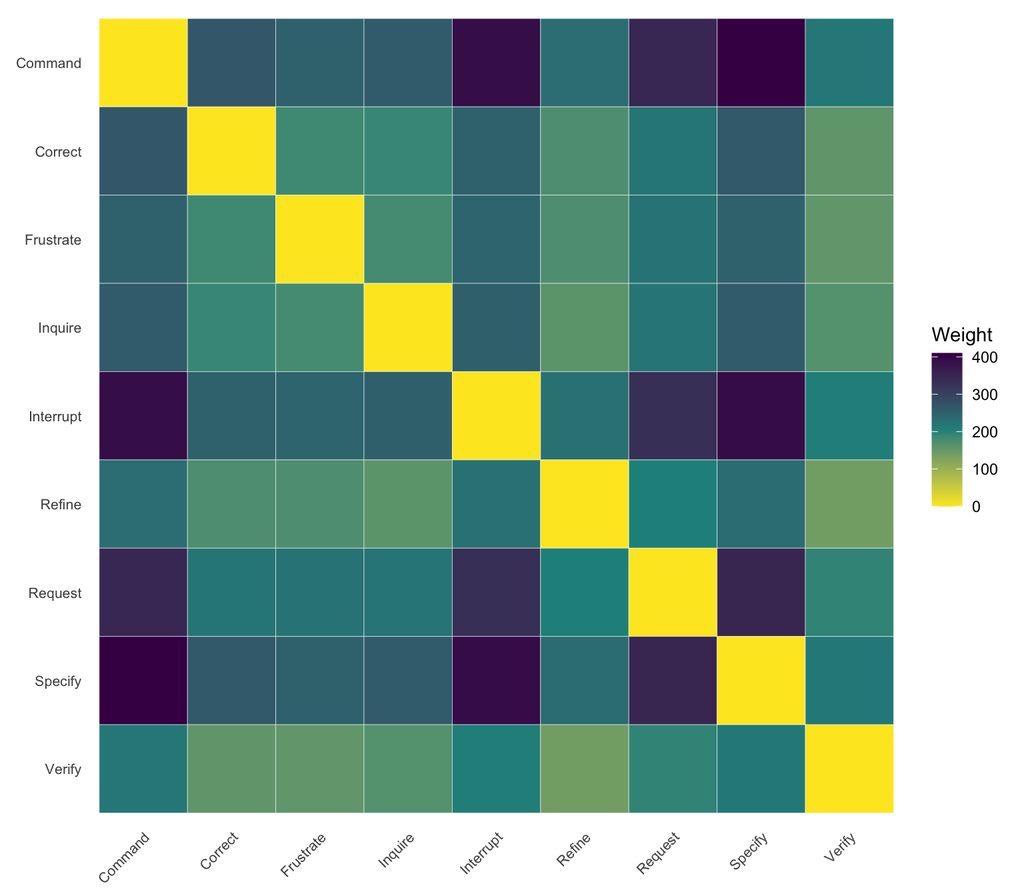

```r
net <- clique_expansion(hg)
plot_heatmap(net)
```

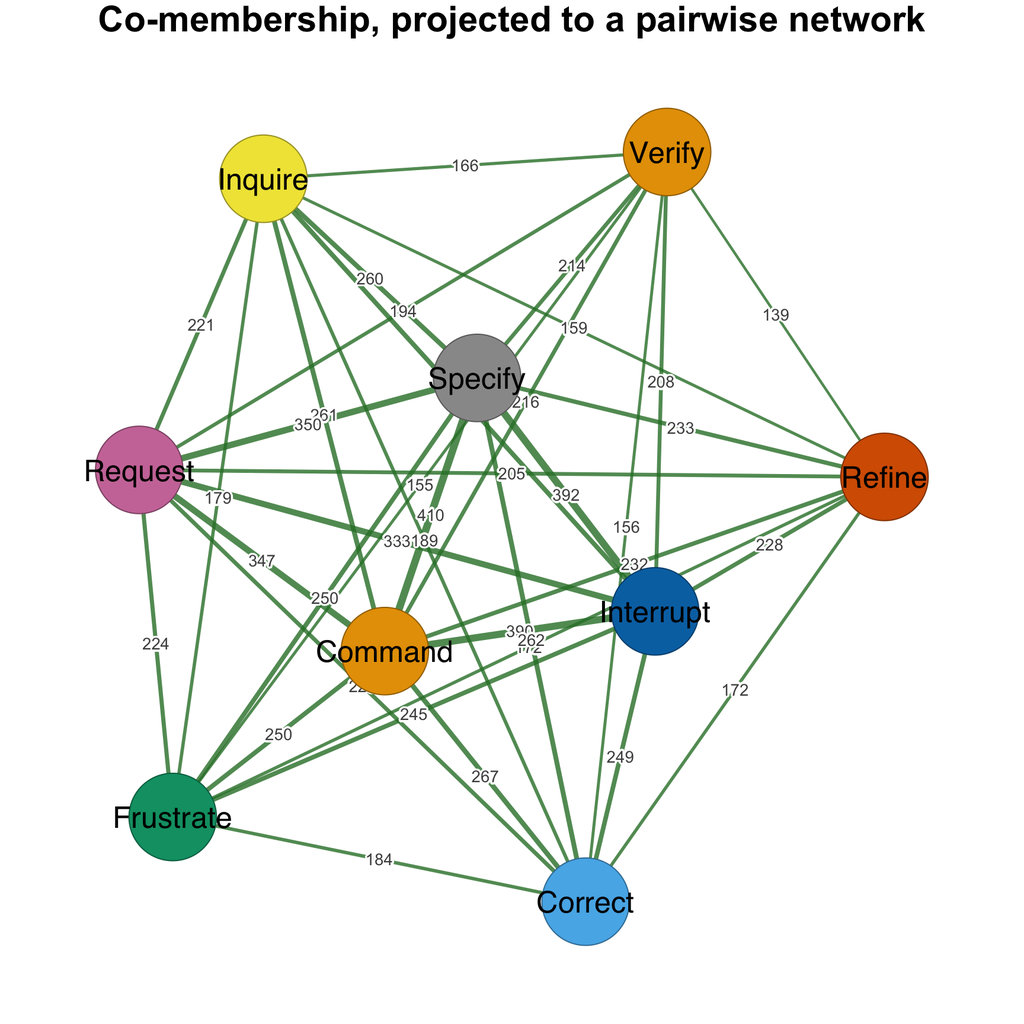

```r
splot(net, minimum = 0.05,
      title = "Co-membership, projected to a pairwise network")
```

### The intersection profile

The most distinctively hypergraph-shaped output, shown by `print()`: how many *pairs of hyperedges* share exactly k members.

```r
m
```

```
Hypergraph measures: 9 nodes, 429 hyperedges
  Density:                0.7293
  Mean edge size:         6.56
  Pairwise participation: 1.0000

  Hyperdegree:    min=218  med=268.0  max=423
  Node strength:  min=1666.0  med=1967.0  max=2796.0
  Edge sizes:     min=1  med=7.0  max=9

Intersection profile (pair counts by overlap size):
  overlap_0   : 96
  overlap_1   : 2960
  overlap_2   : 3235
  overlap_3   : 10827
  overlap_4   : 18272
  overlap_5   : 20355
  overlap_6   : 15746
  overlap_7   : 10601
  overlap_8   : 6554
  overlap_9   : 3160
```

96 pairs of sessions share no codes at all; 20,355 pairs share five. Read as a distribution, it says these sessions are **highly overlapping** — the typical pair has five codes in common. A collection of specialised, disjoint groups would put its mass at the low end instead.

This is a property of the *set system*. No pairwise projection retains it.

### A contrasting example

```r
disjoint <- group_hypergraph(
  data.frame(member = c("A","B","C","D","E","F"),
             grp    = c("g1","g1","g2","g2","g3","g3"),
             stringsAsFactors = FALSE),
  actor = "member", group = "grp")
md <- hypergraph_measures(disjoint)
as.data.frame(md, what = "global")
```

```
                 measure value
1                n_nodes   6.0
2           n_hyperedges   3.0
3                density   0.2
4          avg_edge_size   2.0
5 pairwise_participation   0.2
```

```r
md
```

```
Hypergraph measures: 6 nodes, 3 hyperedges
  Density:                0.2000
  Mean edge size:         2.00
  Pairwise participation: 0.2000

  Hyperdegree:    min=1  med=1.0  max=1
  Node strength:  min=2.0  med=2.0  max=2.0
  Edge sizes:     min=2  med=2.0  max=2

Intersection profile (pair counts by overlap size):
  overlap_0   : 3
```

### On an inferred hypergraph

```r
set.seed(1)
mat <- matrix(runif(100), 10, 10)
mat <- (mat + t(mat)) / 2
diag(mat) <- 0
dimnames(mat) <- list(LETTERS[1:10], LETTERS[1:10])
hg_thr <- build_hypergraph(mat, threshold = 0.5)
mi <- hypergraph_measures(hg_thr)
as.data.frame(mi, what = "global")
```

```
                 measure      value
1                n_nodes 10.0000000
2           n_hyperedges 39.0000000
3                density  0.2384615
4          avg_edge_size  2.3846154
5 pairwise_participation  0.5333333
```

```r
as.data.frame(mi, sort_by = "hyperdegree", top = 4)
```

```
  node hyperdegree node_strength max_edge_size
1    E          13            33             3
2    A          12            30             3
3    D          11            28             3
4    I          11            28             3
```

Clique-derived hypergraphs have much lower density, because most hyperedges are size 2 or 3 rather than spanning most of the node set.

### What to do next

- **`hypergraph_centrality()`** — ranking nodes, where hyperdegree does not separate them.
- **`hypergraph_cluster()`** — grouping nodes using the hypergraph’s random walk.
- **`clique_expansion()`** — the projection, and what it costs.
- **`q_analysis()`** — the overlap question again, in the simplicial family, where subset closure is assumed.

### References

- Lee, G., Choe, M., & Shin, K. (2024). A survey on hypergraph representation, learning and mining. *Data Mining & Knowledge Discovery*, 37, 1-39.
- Do, M. T., Yoon, S., Hooi, B., & Shin, K. (2020). Structural patterns and generative models of real-world hypergraphs. *KDD 2020*, 176-186.

## Hypergraph PageRank: where the interaction flow spends its time

### The analytic question

The windowed-hyperedge tutorial established which action combinations recur in the `human_long` pair-programming sessions and which actions anchor them structurally (H-eigenvector centrality). This tutorial asks a different question: **if session activity is treated as a flow that wanders from action to action through the recurrent combinations, where does that flow spend its time?**

Structural centrality and flow centrality can disagree. An action can sit in many *distinct* combinations (structurally well-placed) while the combinations it sits in are rarely *travelled* (little flow). The instrument for the flow question is the random walk on hypergraphs with edge-dependent vertex weights of Chitra & Raphael (2019), damped in the PageRank manner: from an action, the walk picks one of its recurrent combinations with probability proportional to the combination’s window count, then a member action with probability proportional to its occurrences inside that combination; with probability 0.15 it teleports to a uniformly random action. `hypergraph_centrality(type = "pagerank")` returns the stationary distribution of this walk.

One theoretical point makes the hypergraph version worth having: Chitra & Raphael prove that with edge-*independent* vertex weights the walk collapses to an ordinary PageRank on a weighted pairwise graph. The windowed construction is exactly the case that does *not* collapse — its incidence cells are within-window occurrence totals, which differ across combinations — so the scores below use information a pairwise reduction would destroy.

```r
library(honets)
```

```r
library(cograph)
```

### The flow scores

The hypergraph is the same recurrent structure as in the previous tutorial: three-turn sliding windows, singletons removed, combinations kept when they recur in at least 50 windows.

```r
hg <- window_hypergraph(human_long, action = "code",
                        actor = "session_id", time = "timestamp",
                        window = 3L, min_size = 2L, min_weight = 50L)
hypergraph_centrality(hg, type = "pagerank")
```

```
       node   pagerank
1   Command 0.16951967
2   Correct 0.08046350
3 Frustrate 0.09197984
4   Inquire 0.07915760
5 Interrupt 0.07757647
6    Refine 0.07516957
7   Request 0.10603642
8   Specify 0.27454057
9    Verify 0.04555635
```

The walk spends 27% of its time on Specify and 17% on Command — together almost half of all flow on the two core directive actions. Request is third at 11%. At the other end, Verify receives 4.6%, barely above the teleportation floor: verification is visited, but the recurrent combinations that contain it carry little traffic. The window counts (hyperedge weights) and occurrence totals (vertex weights) are picked up from the hypergraph automatically; no further arguments are needed.

### What recurrence adds to the ranking

Setting every combination’s weight to 1 removes the recurrence information while keeping the combination structure — the walk then treats a combination seen 722 times and one seen 50 times as equal.

```r
hypergraph_centrality(hg, type = "pagerank", edge_weights = 1)
```

```
       node   pagerank
1   Command 0.14355945
2   Correct 0.10068658
3 Frustrate 0.12215641
4   Inquire 0.10413195
5 Interrupt 0.07909551
6    Refine 0.08056093
7   Request 0.09455009
8   Specify 0.21278382
9    Verify 0.06247525
```

Two movements stand out against the recurrence-weighted scores above. Frustrate rises from 9.2% to 12.2% and Correct from 8.0% to 10.1%: these actions appear in *many distinct* combinations, so equal weighting favors them. Specify falls from 27.5% to 21.3%. The comparison separates two kinds of prominence — diversity of contexts (unit weights) versus volume of traffic (window counts) — and the default deliberately measures the latter.

### Seeing the flow

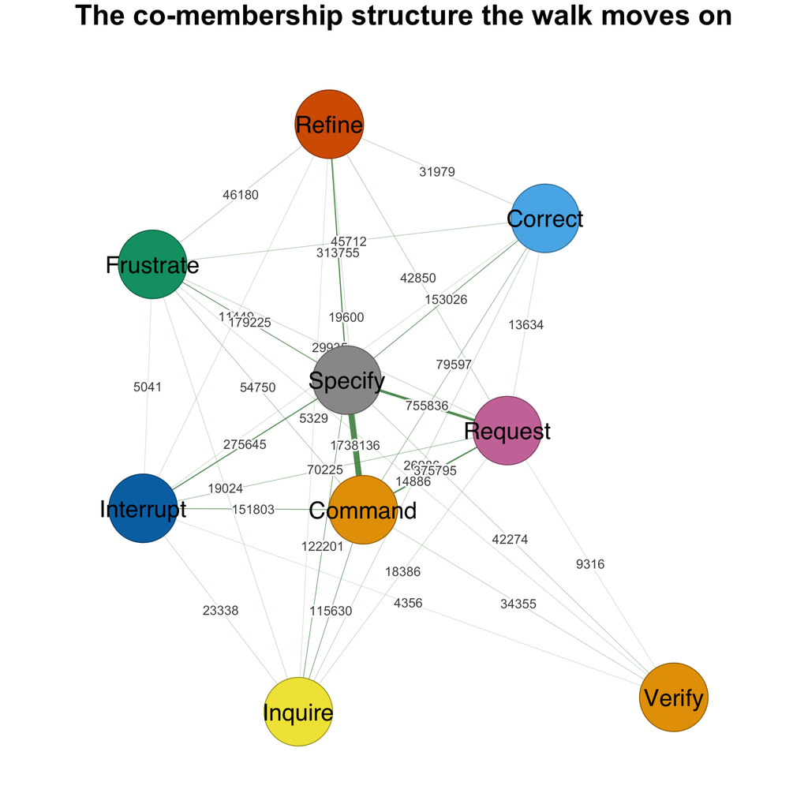

```r
net <- clique_expansion(hg)
splot(net, minimum = 0.05,
      title = "The co-membership structure the walk moves on")
```

### Flow versus structure

The H-eigenvector scores the same hypergraph on presence alone: which actions sit in combinations whose other members are themselves central.

```r
hypergraph_centrality(hg, type = c("H", "pagerank"), sort_by = "pagerank")
```

```
       node         H   pagerank
1   Specify 0.4281911 0.27454057
2   Command 0.3773413 0.16951967
3   Request 0.3043738 0.10603642
4 Frustrate 0.3637328 0.09197984
5   Correct 0.3337657 0.08046350
6   Inquire 0.3340307 0.07915760
7 Interrupt 0.2831700 0.07757647
8    Refine 0.2820356 0.07516957
9    Verify 0.2580999 0.04555635
```

The table is ordered by PageRank, so reading down the `H` column shows where the two measures part company. They agree at the top (Specify, then Command) and at the bottom (Verify last) but disagree in the middle, and the disagreement is informative. H’s third-highest score goes to Frustrate (0.36), and it puts Correct and Inquire (0.33) above Request (0.30); PageRank reverses this, placing Request third (0.11) well above Correct and Inquire (0.08). The reason is the weight layer: Request sits inside the heaviest combinations in the data — `Command, Request, Specify` alone recurs 583 times — while Frustrate, Correct, and Inquire spread across many lighter ones. Structure says Frustrate is well-connected; flow says the traffic runs through Request.

### Is the ranking an artifact of the damping choice?

Damping is the one free parameter, so the conclusion must survive changing it. Two calls bracket the default of 0.85.

```r
hypergraph_centrality(hg, type = "pagerank", damping = 0.5)
```

```
       node   pagerank
1   Command 0.14076338
2   Correct 0.09467131
3 Frustrate 0.10271757
4   Inquire 0.09384650
5 Interrupt 0.09208368
6    Refine 0.09143617
7   Request 0.10586887
8   Specify 0.20117920
9    Verify 0.07743333
```

```r
hypergraph_centrality(hg, type = "pagerank", damping = 0.95)
```

```
       node   pagerank
1   Command 0.17944634
2   Correct 0.07584459
3 Frustrate 0.08761813
4   Inquire 0.07451968
5 Interrupt 0.07335385
6    Refine 0.07001781
7   Request 0.10707234
8   Specify 0.29750537
9    Verify 0.03462188
```

The ordering of all nine actions is identical at damping 0.5, 0.85, and 0.95; only the spread changes. Less teleportation concentrates mass on the structure (Specify grows from 20.1% at 0.5 to 29.8% at 0.95, Verify shrinks from 7.7% to 3.5%), but no two actions trade places. The ranking can be reported without a damping caveat. In the undamped limit the scores converge to the walk’s stationary distribution — the `pi` column that [hypergraph_cluster()] reports, where Specify likewise holds 0.31.

### When to use which

- **`type = "pagerank"`** — the question is about *flow or traffic*: where activity concentrates, weighted by how often combinations recur. It uses both weight layers of a [window_hypergraph()], tolerates disconnected structure (teleportation), and its damping default can be reported without sensitivity caveats when the ranking is stable, as here.
- **`type = "H"` / `"Z"`** — the question is about *structural position* in the combination pattern, deliberately ignoring recurrence. Divergence from PageRank is itself a finding: it locates actions whose prominence is contextual diversity rather than volume.
- **`type = "clique"`** — a pairwise baseline (eigenvector centrality on the clique expansion); useful to check whether the hypergraph adds anything beyond a graph. When the incidence is binary, PageRank too collapses to a pairwise computation — the collapse theorem — so on binary hypergraphs prefer the cheaper graph method and reserve the hypergraph walk for genuinely edge-dependent weights.
- **`pi` from [hypergraph_cluster()]** — the undamped stationary distribution; appropriate when the hypergraph is connected and no teleportation smoothing is wanted.

### References

- Benson, A. R. (2019). Three hypergraph eigenvector centralities. *SIAM Journal on Mathematics of Data Science*, 1(2), 293–312.
- Chitra, U., & Raphael, B. J. (2019). Random walks on hypergraphs with edge-dependent vertex weights. *ICML 2019*, PMLR 97, 1172–1181.
- Hayashi, K., Aksoy, S. G., Park, C. H., & Park, H. (2020). Hypergraph random walks, Laplacians, and clustering. *CIKM 2020*, 495–504.

## The hypergraph Laplacian family

### The analytic question

Spectral methods — clustering, label propagation, diffusion — all run off a Laplacian. Defining one for a hypergraph is not automatic, because a hyperedge connects many nodes at once and there is no single obvious way to distribute that connection.

This family implements two answers:

- **`type = "zhou"`** (default) — the weighted normalised Laplacian of Zhou, Huang & Schölkopf (2006). Each hyperedge spreads its weight evenly over its members.
- **`type = "random_walk"`** — the edge-dependent vertex weight walk of Hayashi et al. (2020). A step picks a hyperedge in proportion to its weight, then a node within it in proportion to that node’s weight *in that hyperedge*. When those within-edge weights vary, this carries information the Zhou construction averages away.

```r
library(honets)
hg <- window_hypergraph(human_long, action = "code", actor = "session_id",
                        time = "timestamp",
                        window = 3L, min_size = 2L, min_weight = 50L)
hg
```

```
Hypergraph: 9 nodes, 56 hyperedges
Size distribution:
  size_2   : 22
  size_3   : 34
Source: windowed sequences, window = 3, step = 1 (9942 windows from 429 sequences)
```

### The Laplacian itself

```r
L <- hypergraph_laplacian(hg)
dim(L)
```

```
[1] 9 9
```

```r
round(L[1:4, 1:4], 3)
```

```
          Command Correct Frustrate Inquire
Command     0.598  -0.079    -0.057  -0.104
Correct    -0.079   0.607    -0.082  -0.064
Frustrate  -0.057  -0.082     0.595  -0.049
Inquire    -0.104  -0.064    -0.049   0.603
```

It is a symmetric 9×9 matrix with the properties a Laplacian should have:

```r
ev <- sort(eigen(L, symmetric = TRUE, only.values = TRUE)$values)
round(head(ev, 4), 5)
```

```
[1] 0.00000 0.54832 0.58210 0.62009
```

The smallest eigenvalue is exactly 0 — the constant vector is always in the kernel. The **second** eigenvalue (0.548) is the spectral gap: how hard it is to cut this hypergraph in two. A large gap means well-connected, hard to split.

The stationary distribution of the associated walk comes along as an attribute, and the PageRank verb is the damped version of the same walk:

```r
round(sort(attr(L, "pi"), decreasing = TRUE), 4)
```

```
  Specify   Command   Request Frustrate   Correct Interrupt   Inquire    Refine
   0.2963    0.1812    0.1136    0.0853    0.0769    0.0739    0.0720    0.0696
   Verify
   0.0312
```

### Clustering

```r
cl <- hypergraph_cluster(hg, k = 3, seed = 1)
cl
```

```
Hypergraph RDC-Spec spectral clustering (zhou Laplacian)
  Nodes: 9 | Hyperedges: 56 | k: 3
  Cluster sizes: Cluster 1 = 3, Cluster 2 = 3, Cluster 3 = 3
  Eigengap after k: 0.0380
```

```r
as.data.frame(cl)
```

```
       node   cluster         pi       dim1        dim2       dim3
1   Command Cluster 1 0.18122071 -0.7810245  0.60442681  0.1570635
2   Correct Cluster 2 0.07687997 -0.4952601 -0.70250989  0.5110746
3 Frustrate Cluster 2 0.08533727 -0.4845138 -0.77779303 -0.4003553
4   Inquire Cluster 1 0.07203994 -0.4238156  0.18180553  0.8873145
5 Interrupt Cluster 1 0.07387406 -0.5864673  0.70956123  0.3906135
6    Refine Cluster 2 0.06959446 -0.4312876 -0.88020425 -0.1980693
7   Request Cluster 3 0.11361321 -0.8025150  0.40116869 -0.4416258
8   Specify Cluster 3 0.29626044 -0.9914024  0.07437341 -0.1076566
9    Verify Cluster 3 0.03117995 -0.2363572  0.36788673 -0.8993301
```

Three clusters of three. Reading the membership: **Command, Inquire and Interrupt** group together; **Correct, Frustrate and Refine** form a second; **Request, Specify and Verify** a third. The second is recognisably a repair-and-revision cluster, the third a specify-and-check cluster.

`summary()` gives the sizes:

```r
summary(cl)
```

[output not shown]

#### Check the eigengap before trusting `k`

The print method reports **Eigengap after k: 0.0380**. That is small. A well-separated `k`-cluster structure produces a large gap after the `k`-th eigenvalue; a small one means the choice of `k` is not strongly supported by the spectrum.

```r
do.call(rbind, lapply(2:5, function(k) {
  c_k <- hypergraph_cluster(hg, k = k, seed = 1)
  sizes_k <- summary(c_k)
  data.frame(k = k, sizes = paste(sizes_k$size, collapse = "/"))
}))
```

```
  k     sizes
1 2       6/3
2 3     3/3/3
3 4   2/3/3/1
4 5 3/2/2/1/1
```

`k` is your assumption, not a discovery. Report the eigengap alongside it, or show that the conclusion survives several values.

#### Seeding

`hypergraph_cluster()` runs k-means on the spectral embedding, which is stochastic. Pass `seed`:

```r
first <- hypergraph_cluster(hg, k = 3, seed = 1)
second <- hypergraph_cluster(hg, k = 3, seed = 1)
identical(first, second)
```

```
[1] TRUE
```

`nstart` (default 25) controls how many k-means restarts are used; raise it if clusters move between seeds.

### Seeing the clustering

`plot()` gives two diagnostic panels: the Laplacian spectrum with the chosen `k` marked, and the spectral embedding the k-means step actually clustered. The eigengap after `k` is the evidence for (or against) the choice — read the scree panel before believing the assignment.

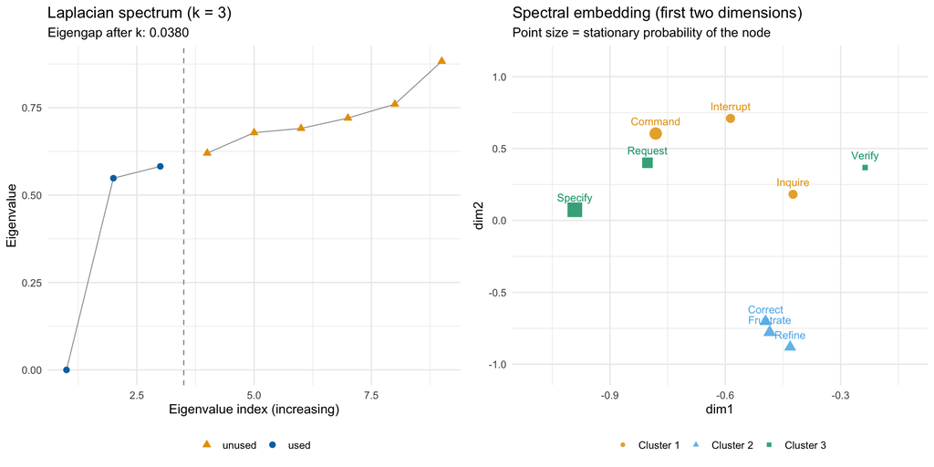

```r
plot(cl)
```

### Transductive label spreading

Label a few nodes, and let the hypergraph structure propagate labels to the rest.

```r
labs <- stats::setNames(c("directive", "evaluative"), c("Command", "Verify"))
tr <- hypergraph_transduction(hg, labels = labs, xi = 0.5)
tr
```

```
Hypergraph transductive label spreading (zhou Laplacian, xi = 0.5)
  Nodes: 9 (2 labeled) | Classes: directive, evaluative
  Predicted: directive = 8, evaluative = 1
```

```r
as.data.frame(tr)
```

```
       node      label  predicted      score     margin
1   Command  directive  directive 0.65562144 0.61843974
2   Correct       <NA>  directive 0.04695511 0.03953534
3 Frustrate       <NA>  directive 0.04030305 0.01306130
4   Inquire       <NA>  directive 0.05563511 0.04829022
5 Interrupt       <NA>  directive 0.05033524 0.03404671
6    Refine       <NA>  directive 0.02593930 0.01867132
7   Request       <NA>  directive 0.06253070 0.03859017
8   Specify       <NA>  directive 0.10786388 0.06510090
9    Verify evaluative evaluative 0.62903274 0.59185104
```

`score` is the confidence in the predicted class; `margin` is the gap to the runner-up. Small margins mean the structure did not decide strongly.

#### The default `xi` can override your own seed labels

`xi` trades off *smoothness over the hypergraph* against *fidelity to the seeds*. It defaults to 0.99, which weights smoothness heavily — heavily enough that a seed label can be overturned:

```r
do.call(rbind, lapply(c(0.1, 0.5, 0.9, 0.99), function(x) {
  fit <- hypergraph_transduction(hg, labels = labs, xi = x)
  d <- as.data.frame(fit)
  data.frame(xi = x,
             Verify_seeded_as = "evaluative",
             Verify_predicted = d$predicted[d$node == "Verify"],
             n_evaluative = sum(d$predicted == "evaluative"))
}))
```

```
    xi Verify_seeded_as Verify_predicted n_evaluative
1 0.10       evaluative       evaluative            1
2 0.50       evaluative       evaluative            1
3 0.90       evaluative       evaluative            1
4 0.99       evaluative        directive            0
```

At `xi = 0.99` — **the default** — Verify is predicted `directive` despite being seeded `evaluative`, and the evaluative class disappears entirely. At `xi ≤ 0.9` the seed holds.

This is the documented behaviour of Zhou’s algorithm, not a bug: with one seed per class and a strongly-connected structure, 99% smoothing swamps the 1% fidelity term. But it means **you must check that your seeds survive**. Lower `xi`, or seed more nodes:

```r
labs2 <- stats::setNames(
  c("directive", "directive", "evaluative", "evaluative"),
  c("Command", "Specify", "Verify", "Correct"))
tr2 <- hypergraph_transduction(hg, labels = labs2, xi = 0.9)
as.data.frame(tr2)
```

```
       node      label  predicted     score     margin
1   Command  directive  directive 0.4961007 0.32723276
2   Correct evaluative evaluative 0.2467516 0.01567389
3 Frustrate       <NA>  directive 0.2383229 0.11568980
4   Inquire       <NA>  directive 0.2278996 0.12670839
5 Interrupt       <NA>  directive 0.2353927 0.13602862
6    Refine       <NA>  directive 0.2173694 0.11675687
7   Request       <NA>  directive 0.2924019 0.16693809
8   Specify  directive  directive 0.5826452 0.36790591
9    Verify evaluative evaluative 0.2143014 0.06177187
```

With two seeds per class the evaluative class survives at the same `xi`.

### Seeing the spreading

The full node-by-class score matrix, with seed nodes outlined in black and each node’s winning class marked. Rows where the winning and runner-up scores are close are the assignments to distrust — that closeness is visible here and invisible in a table of predicted labels.

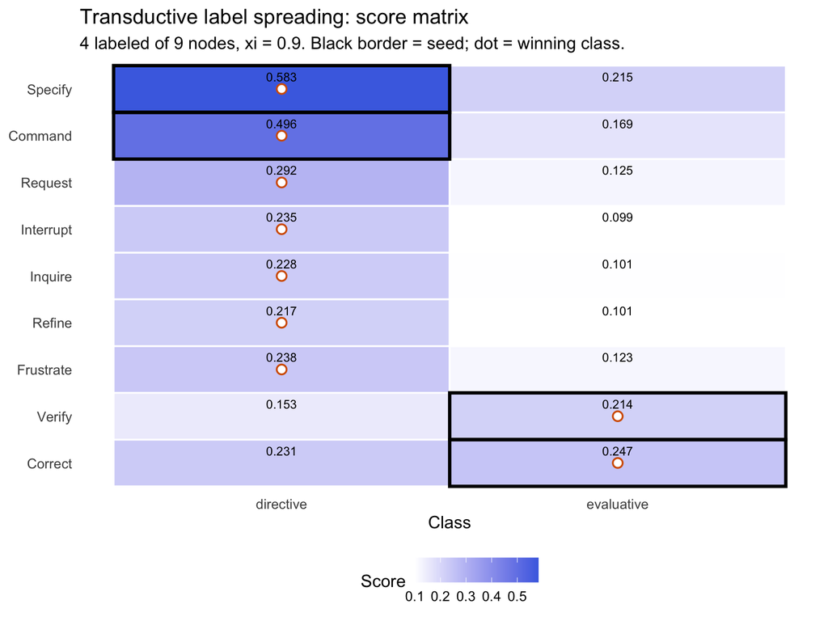

```r
plot(tr2)
```

### Both Laplacians

```r
do.call(rbind, lapply(c("zhou", "random_walk"), function(ty) {
  Lt <- hypergraph_laplacian(hg, type = ty)
  e <- sort(eigen(Lt, symmetric = TRUE, only.values = TRUE)$values)
  data.frame(type = ty, lambda_2 = round(e[2], 4),
             lambda_max = round(max(e), 4))
}))
```

```
         type lambda_2 lambda_max
1        zhou   0.5483     0.8828
2 random_walk   0.5574     0.8749
```

Use `random_walk` when the incidence carries genuinely edge-dependent vertex weights — as `window_hypergraph()` produces, where a cell is an occurrence count within a window. On a binary incidence the two constructions carry the same information, and Chitra & Raphael’s collapse theorem says the walk is then equivalent to one on a weighted clique expansion.

### Connectivity is required

```r
iso <- group_hypergraph(
  data.frame(member = c("A", "B", "C", "D"),
             grp    = c("g1", "g1", "g2", "g2"), stringsAsFactors = FALSE),
  actor = "member", group = "grp")
hypergraph_laplacian(iso)
```

```
Error:
! The hypergraph is not connected; the random walk has no unique stationary distribution. Analyze components separately.
```

A disconnected hypergraph has a degenerate spectrum — the multiplicity of eigenvalue 0 equals the number of components — so these verbs refuse it with a classed `honets_hypergraph_disconnected` condition rather than returning something meaningless. Split the components and analyse them separately.

### What to do next

- **`hypergraph_centrality()`** — the damped version of this same random walk.
- **`hypergraph_measures()`** — descriptive structure before the spectral analysis.
- **`window_hypergraph()`** — where the edge-dependent weights come from.

### References

- Zhou, D., Huang, J., & Schölkopf, B. (2006). Learning with hypergraphs: clustering, classification, and embedding. *NeurIPS 19*, 1601-1608.
- Hayashi, K., Aksoy, S. G., Park, C. H., & Park, H. (2020). Hypergraph random walks, Laplacians, and clustering. *CIKM 2020*, 495-504.
- Chitra, U., & Raphael, B. J. (2019). Random walks on hypergraphs with edge-dependent vertex weights. *ICML 2019*, PMLR 97, 1172-1181.
- von Luxburg, U. (2007). A tutorial on spectral clustering. *Statistics and Computing*, 17(4), 395-416.

## clique_expansion(): projecting back, and what it costs

### The analytic question

Most network tools take a pairwise network. `clique_expansion()` turns a hypergraph into one, so the whole first-order toolkit becomes available — plotting, community detection, standard centralities.

It is also the clearest way to *see* what a hypergraph representation is worth, because the projection is **lossy and irreversible**, and you can measure exactly how much it throws away.

```r
library(honets)
```

```r
library(cograph)
```

### Projecting

Every pair of nodes sharing a hyperedge gets an edge, weighted by how much they share.

```r
hg <- group_hypergraph(human_long, actor = "code", group = "session_id")
net <- clique_expansion(hg)
class(net)
```

```
[1] "netobject"       "cograph_network"
```

```r
summary(net)
```

```
Cograph Network Summary
======================

Structure:
  Nodes: 9
  Edges: 36
  Type: Undirected

Edge Statistics:
  Min weight: 139
  Max weight: 410
  Mean weight: 238.472

Node Labels:
   Command, Correct, Frustrate, Inquire, Interrupt, Refine, Request, Specify, Verify

Layout: not computed
```

```r
w <- hg_project(hg, what = "matrix")
round(w[1:5, 1:5])
```

```
          Command Correct Frustrate Inquire Interrupt
Command         0     267       250     261       390
Correct       267       0       184     189       249
Frustrate     250     184         0     179       245
Inquire       261     189       179       0       253
Interrupt     390     249       245     253         0
```

Nine nodes, 36 edges — the complete graph on nine nodes. Command and Interrupt share 390 sessions; Frustrate and Inquire share 179.

The return is a `netobject` / `cograph_network`, so it drops straight into the packages that consume those.

### What `weighted` actually controls

It binarises the **incidence**, not the output. The output is always a count of shared hyperedges (weighted by incidence values when they exist).

```r
dw <- data.frame(member = c("A", "B", "C", "A", "B"),
                 grp    = c("g1", "g1", "g1", "g2", "g2"),
                 n      = c(2, 5, 3, 1, 4), stringsAsFactors = FALSE)
hw <- group_hypergraph(dw, actor = "member", group = "grp", weight = "n")
as.data.frame(hw, what = "memberships")
```

```
  node hyperedge weight
1    A        g1      2
2    B        g1      5
3    C        g1      3
4    A        g2      1
5    B        g2      4
```

```r
hg_project(hw, weighted = TRUE, what = "matrix")
```

```
   A  B  C
A  0 14  6
B 14  0 15
C  6 15  0
```

```r
hg_project(hw, weighted = FALSE, what = "matrix")
```

```
  A B C
A 0 2 1
B 2 0 1
C 1 1 0
```

With `TRUE`, A-B is `2×5 + 1×4 = 14` — the incidence values multiply. With `FALSE`, A-B is `2` — they simply share two hyperedges.

On a hypergraph whose incidence is already 0/1 the argument does nothing:

```r
hb <- group_hypergraph(dw, actor = "member", group = "grp")
w_true <- hg_project(hb, weighted = TRUE, what = "matrix")
w_false <- hg_project(hb, weighted = FALSE, what = "matrix")
identical(w_true, w_false)
```

```
[1] TRUE
```

### Seeing the projection

The projected object is a `cograph_network`, so it plots directly — which is most of the reason to project at all.

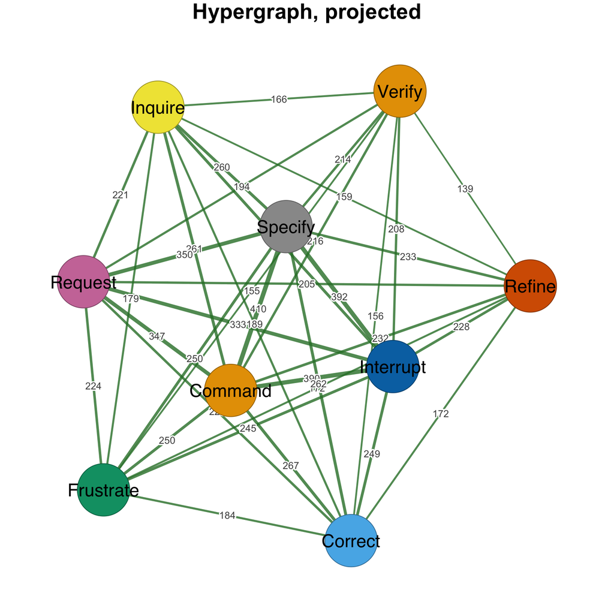

```r
splot(net, minimum = 0.05, title = "Hypergraph, projected")
```

### The information the projection destroys

This is the part worth internalising. Take a hypergraph with two 3-groups, project it, and rebuild a hypergraph from the projection:

```r
d <- data.frame(member = c("A", "B", "C", "A", "B", "D"),
                grp    = c("g1", "g1", "g1", "g2", "g2", "g2"),
                stringsAsFactors = FALSE)
h1 <- group_hypergraph(d, actor = "member", group = "grp")
edges_h1 <- as.data.frame(h1)
edges_h1
```

```
  hyperedge size  states weight
1        g1    3 A, B, C     NA
2        g2    3 A, B, D     NA
```

Two genuine three-way groups. Project:

```r
n1 <- clique_expansion(h1)
n1
```

```
Network (method: clique_expansion) [undirected]
Source: nestimate
  Nodes (4): A, B, C, D
  Edges: 5 / 6 (density: 83.3%)
  Weights: [1.000, 2.000]  |  mean: 1.200
  Strongest edges:
    A -- B  2.000
    A -- C  1.000
    B -- C  1.000
    A -- D  1.000
    B -- D  1.000
Layout: none
```

Rebuild:

```r
h2 <- build_hypergraph(n1, threshold = 0)
edges_h2 <- as.data.frame(h2)
edges_h2
```

```
  hyperedge size  states weight
1        h1    2    A, B     NA
2        h2    2    A, D     NA
3        h3    2    B, D     NA
4        h4    2    A, C     NA
5        h5    2    B, C     NA
6        h6    3 A, B, D     NA
7        h7    3 A, B, C     NA
```

**Two hyperedges went in; seven came out.** The two real triples are recovered — but so are five pairwise edges that were never groups in their own right, only by-products of the projection. A hypergraph and its projection are not interchangeable, and the round trip cannot tell a genuine group from a triangle of coincidences.

That gap is the entire case for `build_hypergraph()`’s `p` parameter: when you *must* infer groups from pairwise data, `p` is where you state how much you believe the inference.

### Projecting collapses the coding sessions completely

```r
m <- hypergraph_measures(hg)
as.data.frame(m, what = "global")
```

```
                 measure       value
1                n_nodes   9.0000000
2           n_hyperedges 429.0000000
3                density   0.7293447
4          avg_edge_size   6.5641026
5 pairwise_participation   1.0000000
```

Pairwise participation is **1.0**: every pair of codes co-occurs somewhere. So the projection is the complete graph, and any first-order centrality on it is near-degenerate — the same saturation that makes the first-order transition network uninformative in the three-families comparison.

```r
deg <- rowSums(w > 0)
range(deg)
```

```
[1] 8 8
```

Every node has degree 8. The hypergraph, meanwhile, still distinguishes the codes clearly by size and overlap structure — see `hypergraph_centrality()`.

### When to use it anyway

- To hand a hypergraph to a tool that only accepts pairwise networks.
- To compare a higher-order result against its first-order counterpart, and show that the higher-order structure is doing work.
- When Chitra & Raphael’s collapse theorem applies: with **edge-independent** vertex weights, a random walk on the hypergraph is *equivalent* to one on the weighted clique expansion. In that case the projection is lossless for walk-based purposes, and the hypergraph adds nothing — which is itself worth knowing, and is why `window_hypergraph()`’s edge-dependent weights matter.

### What to do next

- **`build_hypergraph()`** — the inverse direction, with an explicit belief parameter.
- **`hypergraph_centrality()`** — centrality without projecting.
- **`hypergraph_measures()`** — the overlap structure that projection flattens.

### References

- Chitra, U., & Raphael, B. J. (2019). Random walks on hypergraphs with edge-dependent vertex weights. *ICML 2019*, PMLR 97, 1172-1181.
- Agarwal, S., Branson, K., & Belongie, S. (2006). Higher order learning with graphs. *ICML 2006*, 17-24.
- Tian, Y., & Zafarani, R. (2024). Higher-order network analysis methods. *ACM Computing Surveys*.